# Tidytuesday - Volcano Eruptions

Amri Rohman

25/5/2020

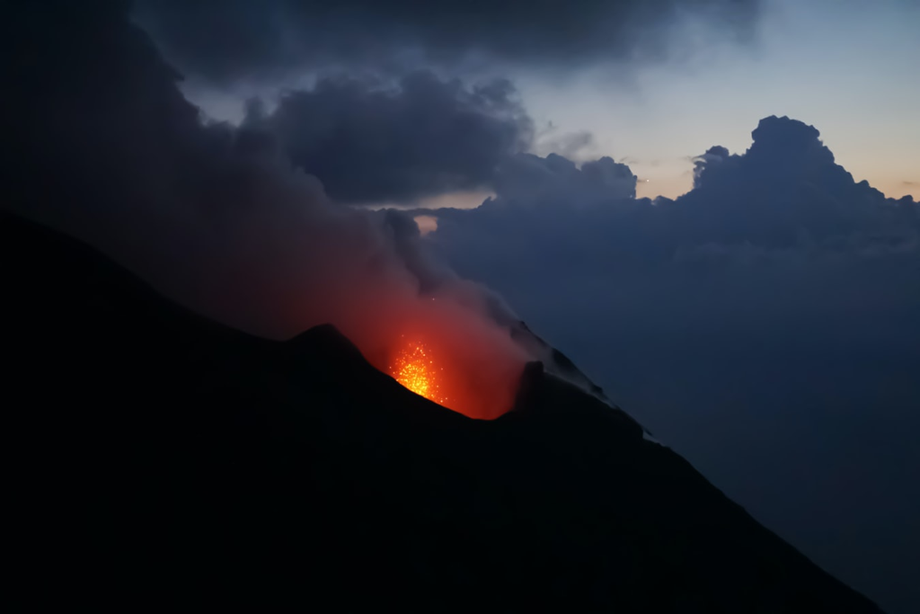

# About Dataset

The data this week comes from [The Smithsonian Institution](https://volcano.si.edu/).

[Axios](https://www.axios.com/chart-every-volcano-that-erupted-since-krakatoa-467da621-41ba-4efc-99c6-34ff3cb27709.html) put together a lovely plot of volcano eruptions since Krakatoa (after 1883) by elevation and type.

For more information about volcanoes check out the below Wikipedia article or specifically about VEI (Volcano Explosivity Index) see the Wikipedia article [here](https://en.wikipedia.org/wiki/Volcanic_Explosivity_Index). Lastly, [Google Earth](https://earth.google.com/web/@8.53508511,-2.91442364,-23163.5821626a,31750897.4603d,35y,0h,0t,0r/data=Ci4SLBIgZmU2MjU5Y2E0Y2FiMTFlODgxOGM3MTM3ODRlMDYzMjMiCGxheWVyc18w) has an interactive site on “10,000 Years of Volcanoes”!

[More Information About Dataset.](https://github.com/rfordatascience/tidytuesday/blob/master/data/2020/2020-05-12/readme.md)

# Loading Library and Data

```r
library(tidyverse)
library(maps)
library(knitr)
library(skimr)

eruptions_raw <- read_csv('https://raw.githubusercontent.com/rfordatascience/tidytuesday/master/data/2020/2020-05-12/eruptions.csv')
volcano_raw <- read_csv('https://raw.githubusercontent.com/rfordatascience/tidytuesday/master/data/2020/2020-05-12/volcano.csv')
```

# Data Preparation

```r
eruptions <- eruptions_raw %>%
  mutate(vei =  case_when(vei == 0 ~ 'non explosie',
                          vei == 1 ~ 'small',
                          vei >= 2 & vei <= 3 ~ 'moderate',
                          vei >= 4 & vei <= 5 ~ 'large',
                          vei >= 6 & vei <= 7 ~ 'very large'),
         start_date = paste(start_year, start_month, start_day, sep = "/") %>% as.Date(),
         end_date = paste(end_year, end_month, end_day, sep = "/") %>% as.Date(),
         durations_days = as.numeric(end_date - start_date)
         ) %>%
  select(-eruption_number, -start_year, -start_month, -start_day,
         -end_year, -end_month, -end_day)


volcano_eruptions <- inner_join(eruptions, volcano_raw, by=c("volcano_number", "volcano_name")) %>%
  select(-c(area_of_activity, latitude.y, longitude.y,
            starts_with(c("major", "minor", "population")))) %>%
  mutate(
        primary_volcano_type = stringr::str_remove_all(primary_volcano_type, "[(s)]"),
        primary_volcano_type = stringr::str_remove_all(primary_volcano_type, "[(es)]"),
        primary_volcano_type = stringr::str_remove_all(primary_volcano_type, "[?]")) %>%
  na.omit()

volcano_eruptions %>%
  select(1:5, country) %>%
  head() %>%
  kable()
```

| volcano_number | volcano_name | eruption_category | vei | evidence_method_dating | country |
| --- | --- | --- | --- | --- | --- |
| 241040 | Whakaari/White Island | Confirmed Eruption | moderate | Historical Observations | New Zealand |
| 290240 | Sarychev Peak | Confirmed Eruption | moderate | Historical Observations | Russia |
| 263310 | Tengger Caldera | Confirmed Eruption | moderate | Historical Observations | Indonesia |
| 256010 | Tinakula | Confirmed Eruption | moderate | Historical Observations | Solomon Islands |
| 357040 | Planchon-Peteroa | Confirmed Eruption | small | Historical Observations | Chile |
| 282050 | Kuchinoerabujima | Confirmed Eruption | moderate | Historical Observations | Japan |

# Summary

### Numeric Variable

```r
volcano_eruptions %>%
  skim() %>%
  yank('numeric') %>%
  select(-p0, -p25, -p75, -p100) %>%
  kable()
```

| skim_variable | n_missing | complete_rate | mean | sd | p50 | hist |
| --- | --- | --- | --- | --- | --- | --- |
| volcano_number | 0 | 1 | 287533 | 43916 | 282110 | ▃▇▆▃▂ |
| latitude.x | 0 | 1 | 12 | 28 | 12 | ▁▂▇▇▃ |
| longitude.x | 0 | 1 | 53 | 107 | 109 | ▁▃▂▂▇ |
| durations_days | 0 | 1 | 374 | 2409 | 40 | ▇▁▁▁▁ |
| elevation | 0 | 1 | 2212 | 1235 | 2084 | ▁▂▇▆▁ |

Here, the volcano, number, longitude and latitude attributes can be ignored, because they don’t mean anything.

### Character Variable

```r
volcano_eruptions %>%
  skim() %>%
  yank('character') %>%
  select(-whitespace, -empty) %>%
  kable()
```

| skim_variable | n_missing | complete_rate | min | max | n_unique |
| --- | --- | --- | --- | --- | --- |
| volcano_name | 0 | 1 | 3 | 32 | 316 |
| eruption_category | 0 | 1 | 18 | 18 | 2 |
| vei | 0 | 1 | 5 | 12 | 5 |
| evidence_method_dating | 0 | 1 | 10 | 23 | 3 |
| primary_volcano_type | 0 | 1 | 4 | 15 | 14 |
| last_eruption_year | 0 | 1 | 3 | 4 | 116 |
| country | 0 | 1 | 4 | 32 | 48 |
| region | 0 | 1 | 6 | 30 | 19 |
| subregion | 0 | 1 | 4 | 37 | 70 |
| tectonic_settings | 0 | 1 | 35 | 47 | 10 |
| evidence_category | 0 | 1 | 14 | 17 | 2 |

In this dataset contain 316 volcano/mountain name spread across 48 countries with 5 level volcano explosion index (vei).

# Data Exploration

### How about volcano explosive index spreding?

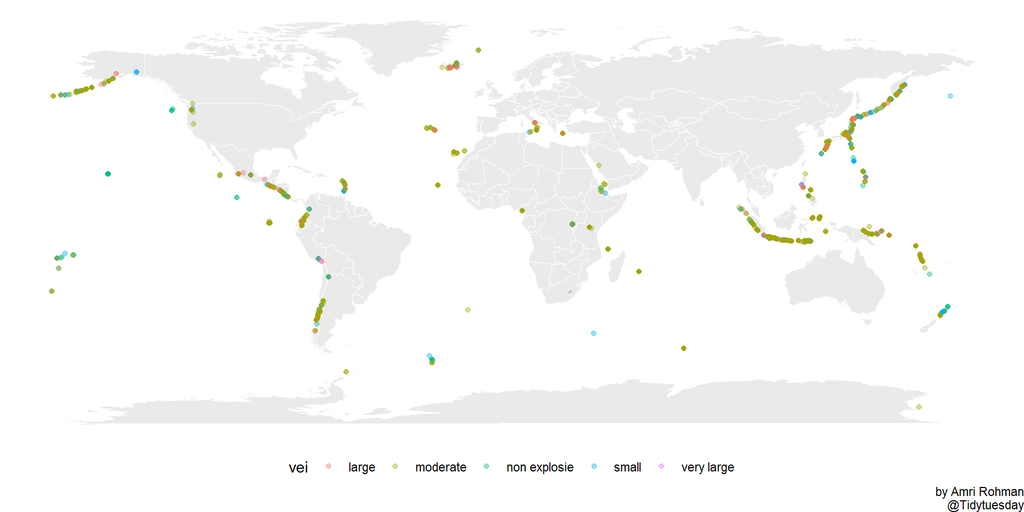

```r
world <- map_data("world")

ggplot() +
  geom_map(
    data = world, map = world,
    aes(long, lat, map_id = region),
    color = "white", fill = "gray20", size = 0.01, alpha = 0.1
  ) +
  geom_point(
    data = volcano_eruptions %>% na.omit(vei),
    aes(longitude.x, latitude.x, color = vei),
    alpha = 0.4
    ) +
  theme_void() +
  #facet_wrap(~vei, ncol = 2) +
  theme(legend.position = 'bottom') +
  labs(caption = "by Amri Rohman\n @Tidytuesday")
```

### What the name mountain which eruption mostly?

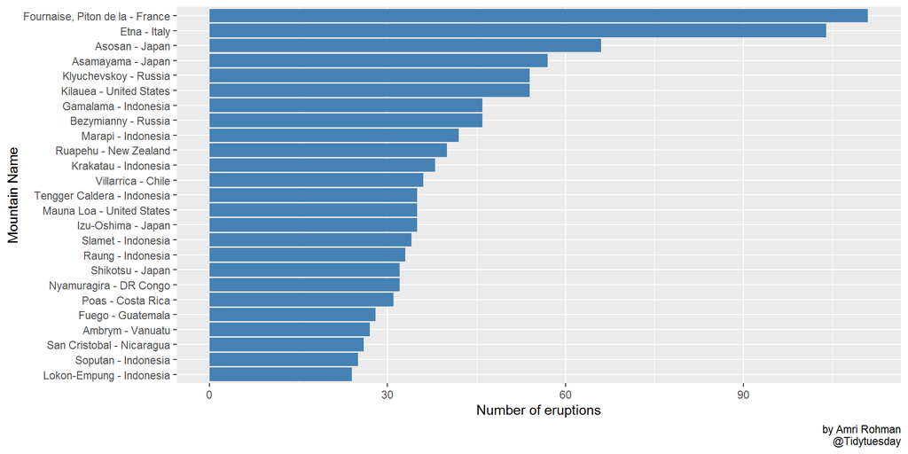

```r
volcano_eruptions %>%
  group_by(country) %>%
  count(volcano_name) %>%
  arrange(-n) %>%
  head(25) %>%
  ggplot(aes(x=reorder(paste(volcano_name, country, sep = " - "), n),
             y=n)) +
  geom_bar(stat='identity', fill="steelblue") +
  coord_flip() +
  theme(legend.position = 'none') +
  labs(x="Mountain Name",
       y="Number of eruptions",
       caption = "by Amri Rohman\n @Tidytuesday")
```

Mount Fournaise, Piton de la has eruptions 111 times, following by mount Etna in Italy has 104 times and Asosan in Japan 66 times.

# Thank You

Amri Rohman.  
Sidoarjo, East Java, ID